# Kernel-Operations for Long-read Insertion, Breakpoint & Recombination Inspection

kolibri

# Overview

This vignette shows a typical workflow for **kolibri** (**K**ernel-Operations for **L**ong-read **I**nsertion, **B**reakpoint & **R**ecombination **I**nspection).  
The goal is to:

1. read a long-read alignment in simplified BED12-like form,
2. filter to split reads,
3. cluster nearby split segments,
4. build a *shared-read* network of those clusters,
5. visualize the network, and
6. zoom in on individual clusters / nodes, including kernel-density inspection of read breakpoints.

All functions below are assumed to be defined in `package_functions.R` or exported by the package.

## 1. Load package functions

```r
source("package_functions.R")
```

## 2. Read alignment as BED12-like table

Input is typically generated with something like

```bash
bedtools bamtobed -bed12 -i alignVA2.bam > alignVA2.bed12
```

We read it with a simplified reader (one block per line is expected; if `blockCount > 1`, the reader will message).

```r
bed12 <- read_bed12("alignVA2.bed12")
head(bed12)
```

```
#> Key: <chrom, start, end>
#>     chrom start   end                                  name score strand
#>    <char> <int> <int>                                <char> <int> <char>
#> 1:   Chr1  1905  5065 m84066_250609_234449_s3/162007687/ccs    60      -
#> 2:   Chr1  2115  6730 m84066_250609_234449_s3/136711487/ccs    60      -
#> 3:   Chr1  2255  6252 m84066_250609_234449_s3/186781308/ccs    60      +
#> 4:   Chr1  2539 14708 m84066_250609_234449_s3/110892164/ccs    60      -
#> 5:   Chr1  2725 10145  m84066_250609_234449_s3/41618301/ccs    60      -
#> 6:   Chr1  2924 11757  m84066_250609_234449_s3/94896987/ccs    60      -
#>    thickStart thickEnd itemRgb blockCount blockSizes blockStarts is_split
#>         <int>    <int>  <char>      <int>     <char>      <char>   <lgcl>
#> 1:       1905     5065 255,0,0          1       3160           0    FALSE
#> 2:       2115     6730 255,0,0          1       4615           0    FALSE
#> 3:       2255     6252 255,0,0          1       3997           0    FALSE
#> 4:       2539    14708 255,0,0          1      12169           0    FALSE
#> 5:       2725    10145 255,0,0          1       7420           0    FALSE
#> 6:       2924    11757 255,0,0          1       8833           0    FALSE
#>    aligned_length nameN
#>             <int> <int>
#> 1:           3160     1
#> 2:           4615     1
#> 3:           3997     1
#> 4:          12169     1
#> 5:           7420     1
#> 6:           8833     1
```

## 3. Filter to split reads

A reasonable starting filter is:

- keep nuclear + organelle chromosomes of interest,
- keep only reads that appear more than once (`nameN > 1`),
- keep only decent mappings (`score > 30`),
- keep sufficiently long aligned fragments (`aligned_length > 500`).

You can tighten or relax these.

```r
split_reads <- bed12[chrom %in% paste0("Chr", c(1, 2, 3, 4, 5, "M")) &
                       nameN > 1 &
                       score > 30 &
                       aligned_length > 500]
split_reads
```

```
#> Key: <chrom, start, end>
#>        chrom   start     end                                  name score strand
#>       <char>   <int>   <int>                                <char> <int> <char>
#>    1:   Chr1  209610  218350  m84066_250609_234449_s3/54003560/ccs    60      +
#>    2:   Chr1  366749  367692  m84066_250609_234449_s3/38342111/ccs    60      -
#>    3:   Chr1  385290  387303 m84066_250609_234449_s3/195559936/ccs    60      +
#>    4:   Chr1  995301  997649 m84066_250609_234449_s3/157419522/ccs    60      -
#>    5:   Chr1 2341760 2345476  m84066_250609_234449_s3/52889609/ccs    60      -
#>   ---
#> 1822:   ChrM  301924  309159 m84066_250609_234449_s3/249304230/ccs    33      -
#> 1823:   ChrM  301924  309241  m84066_250609_234449_s3/96605963/ccs    33      -
#> 1824:   ChrM  302130  306928  m84066_250609_234449_s3/25432054/ccs    52      +
#> 1825:   ChrM  302130  308089  m84066_250609_234449_s3/53936504/ccs    41      -
#> 1826:   ChrM  302130  308585 m84066_250609_234449_s3/150339755/ccs    38      -
#>       thickStart thickEnd itemRgb blockCount blockSizes blockStarts is_split
```

[output cut: 25 more lines]

## 4. Sweep-cluster the split segments

Here we group nearby segments from the same read name into *clusters* along the chromosome.  
`delta` controls how far apart two segments can be to still belong to the same sweep;  
`warn_if_clusters_closer_than` emits a message if two clusters end up very close, so you can re-run with a different `delta`.

```r
clusters_sw <- cluster_reads_sweep(
  split_reads,
  delta = 1000,                     # distance threshold to potentially merge
  warn_if_clusters_closer_than = 5000  # warn if two clusters end up too close
)
```

```
#>     chrom cluster_a cluster_b dist_bp
#>    <char>     <int>     <int>   <num>
#> 1:   Chr1        61        62  3253.5
```

```r
head(clusters_sw)
```

```
#>     chrom   start     end                                  name score strand
#>    <char>   <int>   <int>                                <char> <int> <char>
#> 1:   Chr1  209610  218350  m84066_250609_234449_s3/54003560/ccs    60      +
#> 2:   Chr1  366749  367692  m84066_250609_234449_s3/38342111/ccs    60      -
#> 3:   Chr1  385290  387303 m84066_250609_234449_s3/195559936/ccs    60      +
#> 4:   Chr1  995301  997649 m84066_250609_234449_s3/157419522/ccs    60      -
#> 5:   Chr1 2341760 2345476  m84066_250609_234449_s3/52889609/ccs    60      -
#> 6:   Chr1 2869935 2872415 m84066_250609_234449_s3/118952962/ccs    60      -
#>    thickStart thickEnd itemRgb blockCount blockSizes blockStarts is_split
#>         <int>    <int>  <char>      <int>     <char>      <char>   <lgcl>
#> 1:     209610   218350 255,0,0          1       8740           0    FALSE
#> 2:     366749   367692 255,0,0          1        943           0    FALSE
#> 3:     385290   387303 255,0,0          1       2013           0    FALSE
#> 4:     995301   997649 255,0,0          1       2348           0    FALSE
#> 5:    2341760  2345476 255,0,0          1       3716           0    FALSE
#> 6:    2869935  2872415 255,0,0          1       2480           0    FALSE
#>    aligned_length nameN cluster_id cluster_n chrom_cluster_id
#>             <int> <int>      <int>     <int>           <char>
#> 1:           8740     2          1         1      Chr1_213980
#> 2:            943     2          2         1      Chr1_367220
#> 3:           2013     2          3         1      Chr1_386296
#> 4:           2348     2          4         1      Chr1_996475
#> 5:           3716     2          5         1     Chr1_2343618
#> 6:           2480     2          6         1     Chr1_2871175
```

At this point every row should have, among other things, a **cluster id** and a **chromosome+position label** (e.g. `Chr1_12953910`).

## 5. Build the shared-read network

Two clusters are connected (i.e. an *edge* is created) if they share at least one read name.  
We keep the per-cluster averages (score, length) and also per-edge averages over the shared reads.

```r
net <- build_cluster_network(
  clusters_sw,
  cluster_col = "chrom_cluster_id",
  read_col    = "name",
  chrom_col   = "chrom",
  id_col      = "cluster_id",
  min_shared  = 1
)

head(net$nodes, 20)
```

```
#>           cluster edge_count  chrom cluster_n node_avg_score node_avg_len
#>            <char>      <int> <char>     <int>          <num>        <num>
#>  1:  Chr2_7353953         23   Chr2       237       47.10549     3705.376
#>  2:  Chr2_3710923          4   Chr2       101       47.35644     4863.366
#>  3:    ChrM_11698          1   ChrM        91       54.07692     1683.165
#>  4: Chr1_12953910          6   Chr1        67       59.19403     2603.209
#>  5: Chr2_12514361         10   Chr2        47       60.00000     3576.489
#>  6: Chr3_19489556          1   Chr3        20       60.00000     3969.150
#>  7: Chr4_20457248          1   Chr4        18       60.00000     5302.944
#>  8: Chr1_27921478          1   Chr1        17       60.00000     3656.647
#>  9: Chr2_13597616          1   Chr2        17       60.00000     5217.765
#> 10: Chr1_14979947          2   Chr1        16       44.25000     4898.812
#> 11:  Chr4_9004183          1   Chr4        16       60.00000     3203.938
#> 12:  Chr4_9607840          1   Chr4        16       60.00000     4487.406
#> 13: Chr2_16651189          1   Chr2        15       60.00000     4539.867
```

[output cut: 31 more lines]

```r
head(net$edges, 20)
```

```
#>          cluster1      cluster2 shared_reads shared_avg_score shared_avg_len
#>            <char>        <char>        <int>            <num>          <num>
#>  1:  Chr2_3710923    ChrM_11698          182         50.02198       3012.473
#>  2: Chr2_12514361 Chr3_19489556           40         60.00000       3713.475
#>  3:  Chr2_7353953 Chr4_20457248           36         52.61111       4204.944
#>  4: Chr1_27921478  Chr2_7353953           34         53.67647       3575.441
#>  5: Chr2_13597616  Chr2_7353953           34         52.38235       4512.529
#>  6: Chr1_12953910  Chr4_9607840           32         60.00000       3443.042
#>  7:  Chr2_7353953  Chr4_9004183           32         54.46875       3302.042
#>  8: Chr2_16651189  Chr2_7353953           30         54.56667       4072.467
#>  9:  Chr2_7353953 Chr4_19470146           28         52.21429       3744.155
#> 10:  Chr2_7353953  Chr5_2846059           28         52.46429       3636.607
#> 11: Chr3_22160999  Chr4_8520336           28         59.92857       2894.250
#> 12: Chr1_12953910  Chr4_6637613           26         56.03846       3683.154
#> 13: Chr2_17405942  Chr2_7353953           26         52.96154       4447.308
#> 14: Chr1_20827052 Chr2_12514361           24         60.00000       3551.389
#> 15:  Chr2_7353953  Chr3_7299346           24         56.50000       3060.750
#> 16: Chr2_16671218  Chr2_7353953           22         54.54545       4061.955
#> 17:  Chr2_7353953 Chr3_23697100           22         54.68182       3961.364
#> 18: Chr1_12953910 Chr2_19378772           20         60.00000       3352.550
#> 19: Chr1_12953910 Chr5_29064313           20         60.00000       3548.650
#> 20: Chr2_20415258  Chr2_7353953           20         53.45000       4389.800
#>          cluster1      cluster2 shared_reads shared_avg_score shared_avg_len
```

```r
head(net$reads, 20)
```

```
#>      chrom    start      end                                  name score strand
#>     <char>    <int>    <int>                                <char> <int> <char>
#>  1:   Chr1  2341760  2345476  m84066_250609_234449_s3/52889609/ccs    60      -
#>  2:   Chr1  3532885  3534214  m84066_250609_234449_s3/33686824/ccs    60      -
#>  3:   Chr1  6412941  6413786 m84066_250609_234449_s3/211815975/ccs    60      +
#>  4:   Chr1  8450764  8452728  m84066_250609_234449_s3/77337743/ccs    60      -
#>  5:   Chr1  9671571  9677783 m84066_250609_234449_s3/175179537/ccs    60      +
#>  6:   Chr1  9673511  9677783  m84066_250609_234449_s3/97849701/ccs    60      +
#>  7:   Chr1  9677202  9677783  m84066_250609_234449_s3/56036534/ccs    60      -
#>  8:   Chr1  9677246  9677783 m84066_250609_234449_s3/106824112/ccs    60      -
#>  9:   Chr1  9677778  9684149 m84066_250609_234449_s3/251991471/ccs    60      +
#> 10:   Chr1  9677778  9686366 m84066_250609_234449_s3/237963679/ccs    60      -
#> 11:   Chr1  9677780  9678863  m84066_250609_234449_s3/97849701/ccs    60      +
#> 12:   Chr1  9677780  9681210 m84066_250609_234449_s3/132256952/ccs    60      +
#> 13:   Chr1 12951826 12955993  m84066_250609_234449_s3/94768425/ccs    60      +
```

[output cut: 54 more lines]

`net$nodes` are your cluster *nodes* (with counts and spans),  
`net$edges` tell you which two clusters shared reads and how many,  
`net$reads` are the original rows filtered to just those reads that participate in exactly **two** kept clusters (so `cluster_n` and `shared_reads` match the final network).

## 6. Plot the network

We can make a simple **ggraph** plot. Here we label everything, cap node sizes at 50, and keep neighbors even if they are below the size threshold.

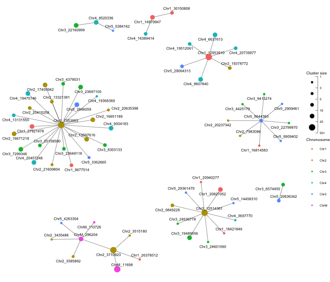

```r
p_label <- plot_cluster_network_ggraph(
  net,
  layout                = "fr",  # force-directed (Fruchterman-Reingold)
  cap                   = 50,
  label                 = TRUE,
  min_cluster_n         = 2,
  label_col             = "cluster",
  alpha_range           = c(1, 1),
  label_size            = 2,
  seed                  = 10,
  keep_neighbors_of_kept = TRUE
)
p_label
```

You can experiment with other layouts (`"kk"`, `"graphopt"`, `"mds"`, `"lgl"`) if the network is long and skinny.

## 7. Plot reads for a cluster and its partners

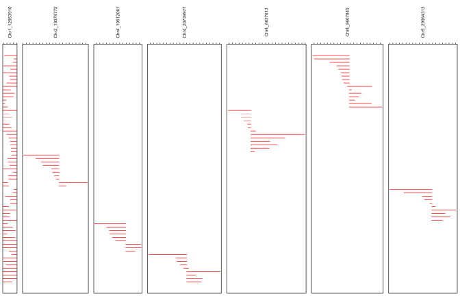

```r
plot_node_reads_by_cluster(
  net,
  node          = "Chr1_12953910",
  primary_color = "red",
  partner_color = "red",
  alpha_col     = "score"
)
```

## 8. Plot reads around a node in the genome

Sometimes you want to see **all** reads that land near a particular cluster anchor (not just split reads in the network).  
Provide the **full** BED (not just the filtered table) and a window size.

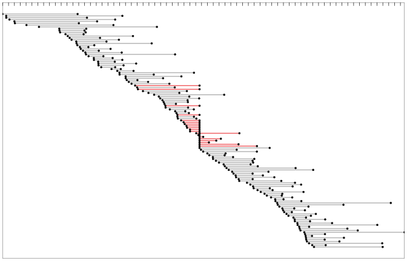

```r
plot_reads_around_node(
  net,
  node        = "Chr4_9607840",
  bed         = bed12,
  window_kb   = 10,
  alpha_col   = "score",
  alpha_range = c(0.3, 1.0)
) +
  ggplot2::geom_point(ggplot2::aes(x = end,   y = y)) +
  ggplot2::geom_point(ggplot2::aes(x = start, y = y))
```

## 9. Extract cluster sequences

If you also have the genome loaded (e.g. with `seqinr::read.fasta()` or `Biostrings::readDNAStringSet()`), you can pull out the actual sequence span for the cluster(s).

```r
# assume `genome` is a named list / DNAStringSet with names like "Chr1", "Chr2", ...
nodes_to_fasta(
  net,
  genome,
  outfile  = "cluster.fa",
  pad_bp   = 0,
  clusters = "Chr1_12953910",
  width    = 10000
)
```

## 10. Inspect breakpoints with kernel density

Finally, we can look at the **start** and **end** positions of all reads that belong to a cluster, run a *reflected* kernel density estimator to avoid edge bias, and overlay it on top of a histogram to spot multimodality (e.g. two breakpoints).

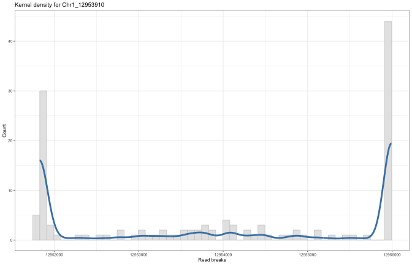

```r
kernels <- plot_node_breaks_kde(net, node = "Chr1_12953910")
kernels$plot
```

And on another node:

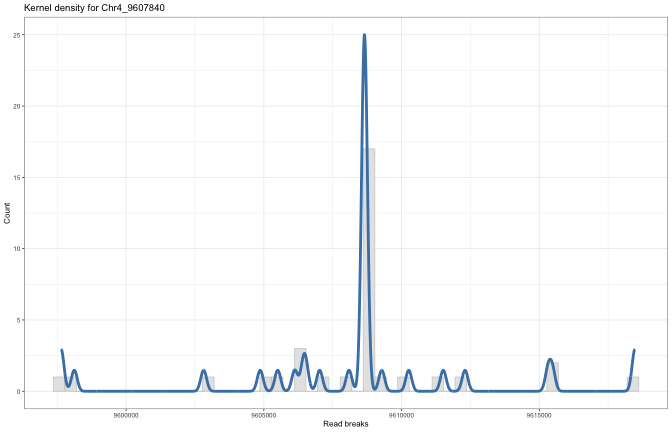

```r
kernels2 <- plot_node_breaks_kde(net, node = "Chr4_9607840")
kernels2$plot
```